# R Assignment 1

Merrick Howarth

Sept. 28 2021

## Introduction

Following I have included my code which reads in data saved from a folder, then compiles the .csv files into a single data frame with units of kBTUs.

```r
# reading in saved csv files for gas and electric from 2017 - now

years <- 2017:2021
quarters <- 1:4
types <- c("Electric", "Gas")

pge_elec_gas <- NULL

for (type in types){
  for (year in years) {
    for (quarter in quarters) {
      filename <-
        paste0("pge/PGE_",year,"_Q",quarter, "_", type, "UsageByZip.csv")


      temp <- read_csv(filename)

      if (type == "Electric"){
        temp$TOTALKWH = temp$TOTALKWH * 3412.14 / 1000  # Convert to kBTU
        names(temp)[names(temp) == 'TOTALKWH'] <- 'TOTALKBTU'

        temp$AVERAGEKWH = temp$AVERAGEKWH * 3412.14 / 1000  # Convert to kBTU
        names(temp)[names(temp) == 'AVERAGEKWH'] <- 'AVERAGEKBTU'
      } else{
        temp$TOTALTHM = temp$TOTALTHM * 99976.1 / 1000  # Convert to kBTU
        names(temp)[names(temp) == 'TOTALTHM'] <- 'TOTALKBTU'

        temp$AVERAGETHM = temp$AVERAGETHM * 99976.1 / 1000  # Convert to kBTU
        names(temp)[names(temp) == 'AVERAGETHM'] <- 'AVERAGEKBTU'
      }

      pge_elec_gas<- rbind(pge_elec_gas,temp)

      saveRDS(pge_elec_gas, "pge_elec_gas.rds")

    }
  }
}
```

## Data Manipulation

Once the data has been compiled into a single dataframe, the information must be manipulated to achieve the ultimate goal. First the data is filtered so only residential data is saved, as this analysis aims to consider residential and commercial consumers separately. Then unnecessary information is removed from the dataframe. Remaining entries are grouped by year, month, and customer class so totals can be compiled for the entire PG&E service area for a given year, month, and energy type. Lastly for plotting ease, a new column is added which identifies the date from the existing month and year columns and the dataframe is then sorted chronologically. The code is then repeated for commercial data.

```r
#sum total usage across all zips in given month, year, and type
pge_res_data <-
  pge_elec_gas %>%

  filter(
         CUSTOMERCLASS %in% c("Elec- Residential","Gas- Residential")
         ) %>%

  select(
         MONTH, YEAR, CUSTOMERCLASS, TOTALKBTU
         ) %>%

  group_by(
           MONTH, YEAR, CUSTOMERCLASS
           )%>%

  summarize(
            TOTALKBTU = sum(TOTALKBTU, na.rm = T)
            )

# setting up date for ordering chronoligcally
pge_res_data$DATE= paste0(pge_res_data$YEAR,"-",pge_res_data$MONTH,"-01") %>%
                    as.Date()

# ordering by date
pge_res_data <- pge_res_data[with(pge_res_data, order(DATE)),]


saveRDS(pge_res_data, "pge_res_data.rds")
```

```r
#sum total usage across all zips in given month, year, and type
pge_com_data <-
  pge_elec_gas %>%

  filter(
         CUSTOMERCLASS %in% c("Elec- Commercial","Gas- Commercial")
         ) %>%

  select(
         MONTH, YEAR, CUSTOMERCLASS, TOTALKBTU
         ) %>%

  group_by(
           MONTH, YEAR, CUSTOMERCLASS
           )%>%

  summarize(
            TOTALKBTU = sum(TOTALKBTU, na.rm = T))


# setting up date for ordering chronoligcally
pge_com_data$DATE= paste0(pge_com_data$YEAR,"-",pge_com_data$MONTH,"-01") %>%
                    as.Date()

# ordering by date
pge_com_data <- pge_com_data[with(pge_com_data, order(DATE)),]

saveRDS(pge_com_data, "pge_com_data.rds")
```

## Plotting

Lastly, data is plotted for ease of interpretation.

```r
# develop graph

pge_res_chart <-
  pge_res_data %>%
  ggplot() +
  geom_bar(
    aes(
      x = DATE %>% factor(),
      y = TOTALKBTU,
      fill = CUSTOMERCLASS
    ),
    stat = "identity",
    position = "stack"
  ) +
  labs(
    x = "Month",
    y = "kBTU",
    title = "PG&E Territory Monthly Residential Gas \n and Electricity Usage, 2017 - Q2 2021",
    fill = "Energy Type"
  ) +
  theme(axis.text.x = element_text(angle = 70, hjust=1)
  )
```

```r
# develop graph of zoomed data
res_data_zoomed <- pge_res_data[49:96, ]

pge_res_chart_zoom <-
  res_data_zoomed %>%
  ggplot() +
  geom_bar(
    aes(
      x = DATE %>% factor(),
      y = TOTALKBTU,
      fill = CUSTOMERCLASS
    ),
    stat = "identity",
    position = "stack"
  ) +
  labs(
    x = "Month",
    y = "kBTU",
    title = "PG&E Territory Monthly Residential Gas \n and Electricity Usage, 2019 - 2020",
    fill = "Energy Type"
  ) +
  theme(axis.text.x = element_text(angle = 70, hjust=1))
```

```r
# develop graph

pge_com_chart <-
  pge_com_data %>%
  ggplot() +
  geom_bar(
    aes(
      x = DATE %>% factor(),
      y = TOTALKBTU,
      fill = CUSTOMERCLASS
    ),
    stat = "identity",
    position = "stack"
  ) +
  labs(
    x = "Month",
    y = "kBTU",
    title = "PG&E Territory Monthly Commercial Gas \n and Electricity Usage, 2017 - Q2 2021",
    fill = "Energy Type"
  )+
  theme(axis.text.x = element_text(angle = 70, hjust=1))
```

```r
# develop graph of zoomed data
com_data_zoomed <- pge_com_data[49:96, ]

pge_com_chart_zoom <-
  com_data_zoomed %>%
  ggplot() +
  geom_bar(
    aes(
      x = DATE %>% factor(),
      y = TOTALKBTU,
      fill = CUSTOMERCLASS
    ),
    stat = "identity",
    position = "stack"
  ) +
  labs(
    x = "Month",
    y = "kBTU",
    title = "PG&E Territory Monthly Commercial Gas \n and Electricity Usage, 2019 - 2020",
    fill = "Energy Type"
  ) +
  theme(axis.text.x = element_text(angle = 70, hjust=1))
```

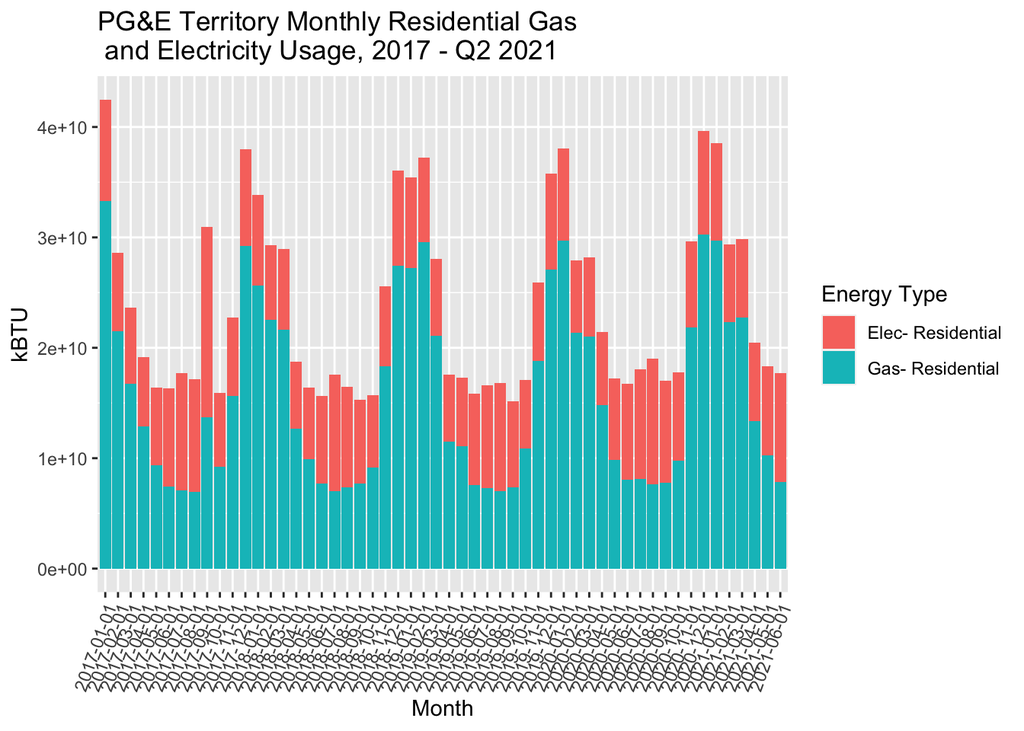

```r
pge_res_chart
```

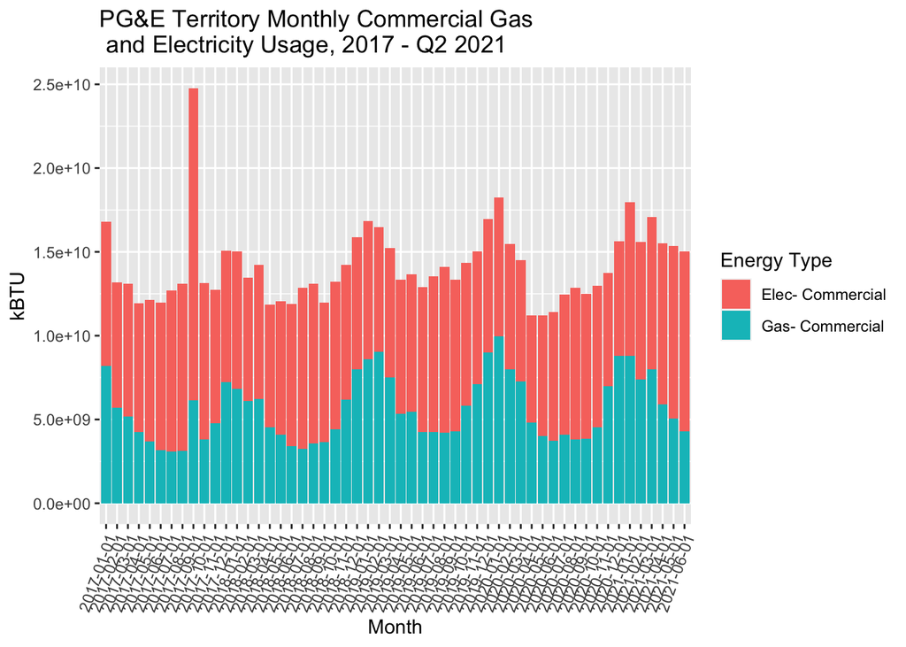

```r
pge_com_chart
```

## Analysis

It should be noted that the data which the plots were made from is identified as "“as is”, with no guarantee of completeness [or] accuracy"

When looking at overall trends over the full 4 years, seasonal changes are easy to see, but finer details required a smaller range for detecting changes, so plots showing 2019-2020 are shown below. From these plots it can bee seen that following the start of the pandemic in March of 2020, commercial energy use went down slightly and residential energy use increased. This is the trends which would be expected as stay at home orders were rolled out across California and people started to spend more time and home and less time out, shifting the energy usage from commercial to residential.

It is also interesting that when looking to 2021, commercial use is back up and is actually higher than the typical pre-pandemic values while residential consumption remains high.

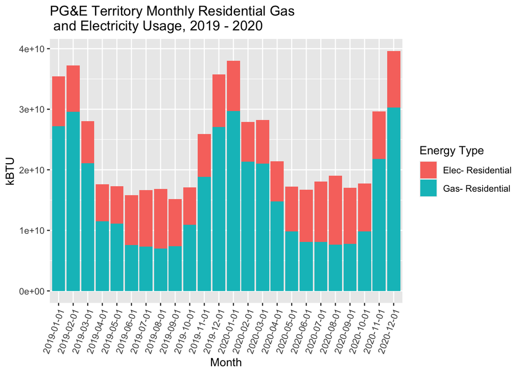

```r
pge_res_chart_zoom
```

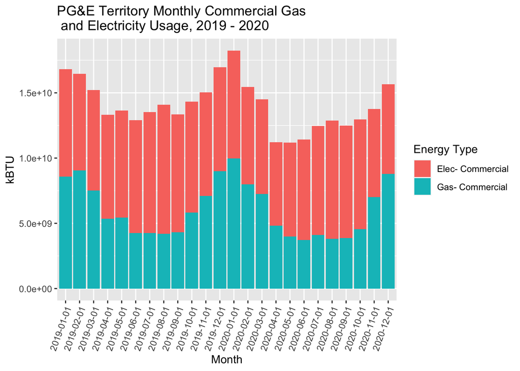

```r
pge_com_chart_zoom
```